# R Notebook

```r
library(tidyverse)
```

# The data set

|  | iso_code | continent | location | date | total_cases | new_cases | new_cases_smoothed | total_deaths | new_deaths | new_deaths_smoothed | total_cases_per_million | new_cases_per_million | new_cases_smoothed_per_million | total_deaths_per_million | new_deaths_per_million | new_deaths_smoothed_per_million | reproduction_rate | icu_patients | icu_patients_per_million | hosp_patients | hosp_patients_per_million | weekly_icu_admissions | weekly_icu_admissions_per_million | weekly_hosp_admissions | weekly_hosp_admissions_per_million | total_tests | new_tests | total_tests_per_thousand | new_tests_per_thousand | … |
| --- | --- | --- | --- | --- | --- | --- | --- | --- | --- | --- | --- | --- | --- | --- | --- | --- | --- | --- | --- | --- | --- | --- | --- | --- | --- | --- | --- | --- | --- | --- |
| 1 | AFG | Asia | Afghanistan | 2020-02-24 | 5 | 5 | NA | NA | NA | NA | 0.126 | 0.126 | NA | NA | NA | NA | NA | NA | NA | NA | NA | NA | NA | NA | NA | NA | NA | NA | NA | … |
| 2 | AFG | Asia | Afghanistan | 2020-02-25 | 5 | 0 | NA | NA | NA | NA | 0.126 | 0.000 | NA | NA | NA | NA | NA | NA | NA | NA | NA | NA | NA | NA | NA | NA | NA | NA | NA | … |
| 3 | AFG | Asia | Afghanistan | 2020-02-26 | 5 | 0 | NA | NA | NA | NA | 0.126 | 0.000 | NA | NA | NA | NA | NA | NA | NA | NA | NA | NA | NA | NA | NA | NA | NA | NA | NA | … |
| 4 | AFG | Asia | Afghanistan | 2020-02-27 | 5 | 0 | NA | NA | NA | NA | 0.126 | 0.000 | NA | NA | NA | NA | NA | NA | NA | NA | NA | NA | NA | NA | NA | NA | NA | NA | NA | … |
| 5 | AFG | Asia | Afghanistan | 2020-02-28 | 5 | 0 | NA | NA | NA | NA | 0.126 | 0.000 | NA | NA | NA | NA | NA | NA | NA | NA | NA | NA | NA | NA | NA | NA | NA | NA | NA | … |
| 6 | AFG | Asia | Afghanistan | 2020-02-29 | 5 | 0 | 0.714 | NA | NA | NA | 0.126 | 0.000 | 0.018 | NA | NA | NA | NA | NA | NA | NA | NA | NA | NA | NA | NA | NA | NA | NA | NA | … |

```r
data_set <- data_set %>%
  filter(!str_detect(iso_code, "^OWID_"))
```

[output not shown]

# Task 0

| year | cases |
| --- | --- |
| 2020 | 82991259 |
| 2021 | 205192696 |
| 2022 | 242824316 |

Let’s define the visualization mapping in aes() and plot nothing, for the beginning:

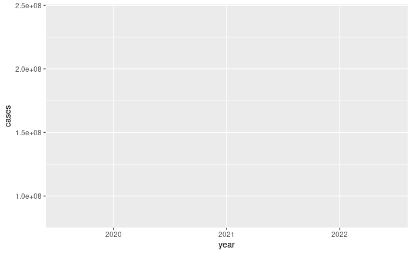

Ok: ggplot2 recognizes my variables and their scales, but plots nothing. I need to add some geoms there for plot to materialize:

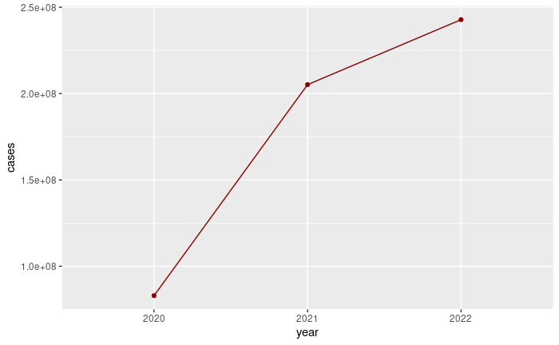

I could have added a different geom:

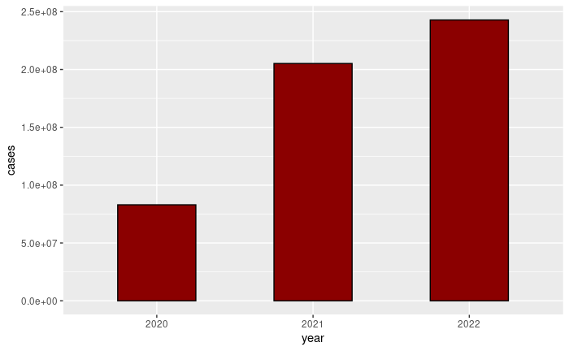

Now, what about total_cases per month and per year? I need a new plot_frame for this:

```r
data_set$year <- substr(data_set$date, 1, 4)
data_set$month <- as.character(substr(data_set$date, 6, 7))
plot_frame <- data_set %>%
  select(total_cases, year, month) %>%
  group_by(year, month) %>%
  summarise(cases = sum(total_cases, na.rm = TRUE))
print(plot_frame)
```

| year | month | cases |
| --- | --- | --- |
| 2020 | 01 | 38557 |
| 2020 | 02 | 1662085 |
| 2020 | 03 | 8955813 |
| 2020 | 04 | 63392483 |
| 2020 | 05 | 145000987 |
| 2020 | 06 | 246675251 |
| 2020 | 07 | 431559080 |
| 2020 | 08 | 671737999 |
| 2020 | 09 | 895044711 |
| 2020 | 10 | 1228857444 |

[output cut: 20 more lines]

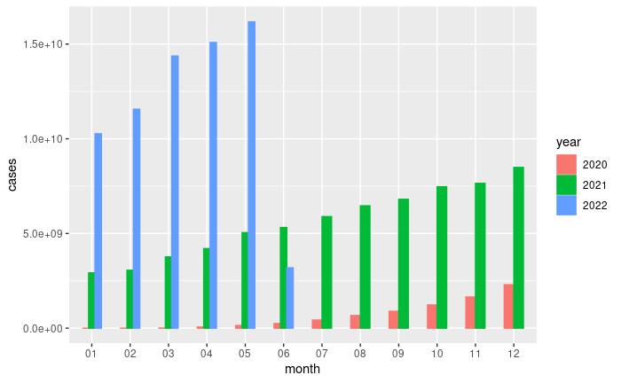

Or I can do facet_wrap:

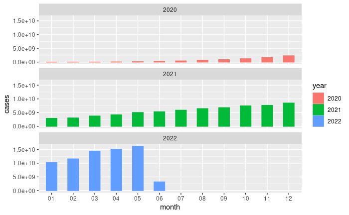

Now I can begin using theme() in order to style my chart.

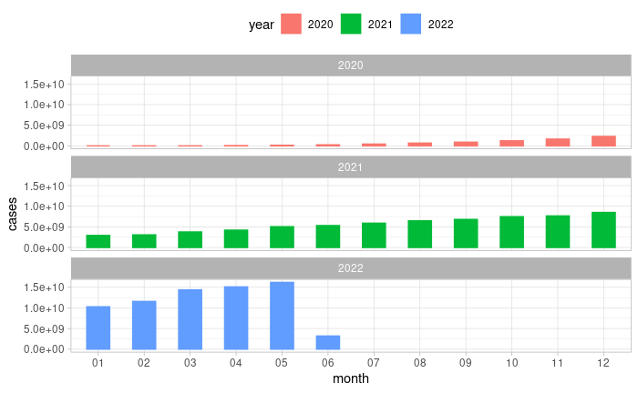

Even better:

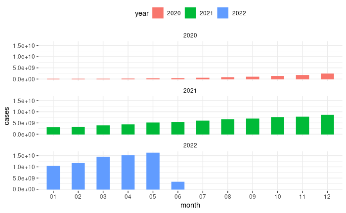

If you want to avoid using the scientific notation on a scale (look at our y-axis), you can use the scales library:

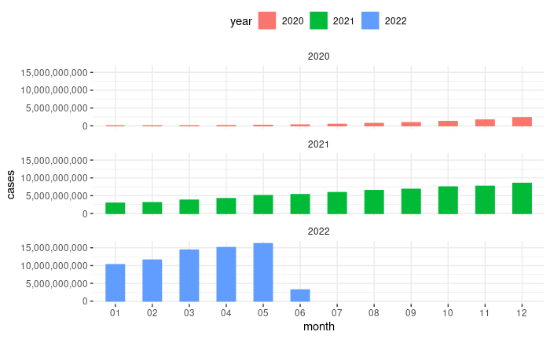

Let’s now produce a scatter plot of the - mean number of new_cases per day, per country - and the country’s population (taking the latest available data).

Population first:

| location | date | population |
| --- | --- | --- |
| Afghanistan | 2022-06-06 | 39835428 |
| Albania | 2022-06-06 | 2872934 |
| Algeria | 2022-06-06 | 44616626 |
| Andorra | 2022-06-06 | 77354 |
| Angola | 2022-06-06 | 33933611 |
| Anguilla | 2022-06-06 | 15125 |
| Antigua and Barbuda | 2022-06-06 | 98728 |
| Argentina | 2022-06-06 | 45605823 |
| Armenia | 2022-06-06 | 2968128 |
| Aruba | 2022-06-06 | 107195 |

[output cut: 219 more lines]

| location | mean_cases_per_day |
| --- | --- |
| Afghanistan | 2.171827e+02 |
| Albania | 3.370915e+02 |
| Algeria | 3.192077e+02 |
| Andorra | 5.226578e+01 |
| Angola | 1.233140e+02 |
| Anguilla | 4.112360e+00 |
| Antigua and Barbuda | 1.029484e+01 |
| Argentina | 1.124439e+04 |
| Armenia | 5.108768e+02 |
| Aruba | 4.670972e+01 |

[output cut: 219 more lines]

Now I need to join cases_set to population_set by locations; if you are interested to learn about relational structures and join operations in dplyr in R, go read section 13 Relational data in R for Data Science.

| location | date | population | mean_cases_per_day |
| --- | --- | --- | --- |
| Afghanistan | 2022-06-06 | 39835428 | 2.171827e+02 |
| Albania | 2022-06-06 | 2872934 | 3.370915e+02 |
| Algeria | 2022-06-06 | 44616626 | 3.192077e+02 |
| Andorra | 2022-06-06 | 77354 | 5.226578e+01 |
| Angola | 2022-06-06 | 33933611 | 1.233140e+02 |
| Anguilla | 2022-06-06 | 15125 | 4.112360e+00 |
| Antigua and Barbuda | 2022-06-06 | 98728 | 1.029484e+01 |
| Argentina | 2022-06-06 | 45605823 | 1.124439e+04 |
| Armenia | 2022-06-06 | 2968128 | 5.108768e+02 |
| Aruba | 2022-06-06 | 107195 | 4.670972e+01 |

[output cut: 219 more lines]

Here goes our scatter plot:

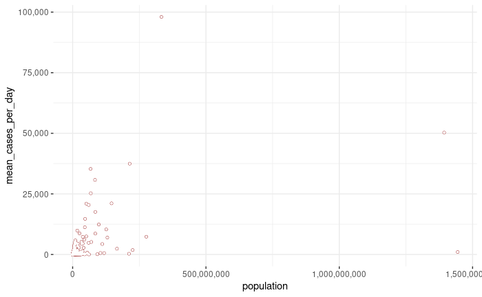

```r
ggplot(data = plot_frame,
       aes(x = population, y = mean_cases_per_day)) +
  geom_point(size = 1, color = "darkred") +
  geom_point(size = .75, color = "white") +
  scale_y_continuous(labels = comma) +
  scale_x_continuous(labels = comma) +
  theme_bw() +
  theme(panel.border = element_blank())
```

Maybe using log() scales?

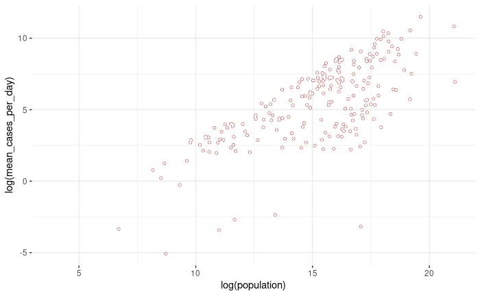

```r
ggplot(data = plot_frame,
       aes(x = log(population),
           y = log(mean_cases_per_day))) +
  geom_point(size = 1, color = "darkred") +
  geom_point(size = .75, color = "white") +
  scale_y_continuous(labels = comma) +
  scale_x_continuous(labels = comma) +
  theme_bw() +
  theme(panel.border = element_blank())
```

We can place the best fitting linear model on the chart by geom_smooth(method=“lm):

```
Warning: Removed 14 rows containing non-finite values (stat_smooth).
Warning: Removed 14 rows containing missing values (geom_point).
Warning: Removed 14 rows containing missing values (geom_point).
```

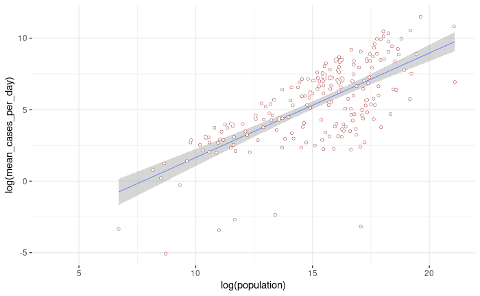

```r
ggplot(data = plot_frame,
       aes(x = log(population),
           y = log(mean_cases_per_day))) +
  geom_smooth(size = .25, method = "lm") +
  geom_point(size = 1, color = "darkred") +
  geom_point(size = .75, color = "white") +
  scale_y_continuous(labels = comma) +
  scale_x_continuous(labels = comma) +
  theme_bw() +
  theme(panel.border = element_blank())
```

## Task 1.

Reuse my code to produce a chart showing the total number of new_cases per continent and per year.

```r
task1_set <- data_set %>%
  select(continent, date, new_cases) %>%
  mutate(year = substr(date, 1, 4)) %>%
  group_by(continent, year) %>%
  summarise(new_cases = sum(new_cases, na.rm = TRUE), count = n())
```

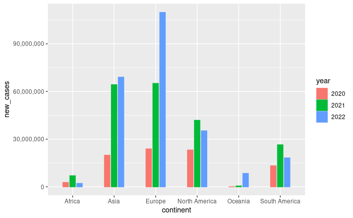

## Task 2.

Reuse my code to produce a scatter plot of: * the mean gdp_per_capita per country, and * the country population_density.

```r
task2_set <- data_set %>%
  select(gdp_per_capita, location, continent, population_density) %>%
  group_by(location, continent) %>%
  summarise(gdp_per_capita_mean=mean(gdp_per_capita, na.rm = TRUE),
            population_density=mean(population_density, na.rm = TRUE))
```

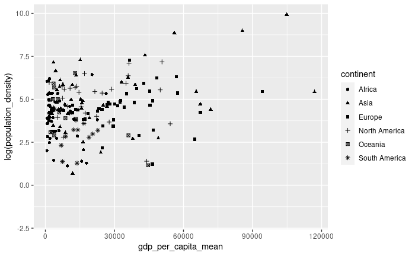

```r
ggplot(data=task2_set,
       mapping=aes(x=gdp_per_capita_mean,
                   y=log(population_density), shape=continent)) +
  geom_point()
```